# Assessment 4 — (R Project)

Naveesha Chamandi (s225448094)

2025-10-04

## Downloading two data files

```r
gene_expr_raw_url <-"https://raw.githubusercontent.com/ghazkha/Assessment4/refs/heads/main/gene_expression.tsv"
growth_raw_url <-"https://raw.githubusercontent.com/ghazkha/Assessment4/refs/heads/main/growth_data.csv"
```

```r
dir.create("data", showWarnings = FALSE)
download.file(gene_expr_raw_url, destfile = "data/gene_expression.tsv", mode = "wb")
download.file(growth_raw_url,    destfile = "data/growth_data.csv",    mode = "wb")
```

# Quick check

```r
file.exists("data/gene_expression.tsv"); file.exists("data/growth_data.csv")
```

```
## [1] TRUE
```

```
## [1] TRUE
```

## 1) Read gene_expression.tsv, set gene IDs as row names, show first 6 (TABLE)

I imported the TSV with read.table, moved the first column (gene IDs) into rownames(), removed that column from the data frame, and displayed the first six rows to check the format.

```r
# Read the gene expression table
expr <- read.table("data/gene_expression.tsv",
                   header = TRUE, sep = "\t",
                   stringsAsFactors = FALSE, check.names = FALSE)

# Make the first column (gene IDs) the row names
rownames(expr) <- expr[[1]]
expr[[1]] <- NULL

# Answer: table of first six genes
head(expr, 6)
```

```
##                               GTEX-1117F-0226-SM-5GZZ7 GTEX-1117F-0426-SM-5EGHI
## ENSG00000223972.5_DDX11L1                            0                        0
## ENSG00000227232.5_WASH7P                           187                      109
## ENSG00000278267.1_MIR6859-1                          0                        0
## ENSG00000243485.5_MIR1302-2HG                        1                        0
## ENSG00000237613.2_FAM138A                            0                        0
## ENSG00000268020.3_OR4G4P                             0                        1
##                               GTEX-1117F-0526-SM-5EGHJ
## ENSG00000223972.5_DDX11L1                            0
## ENSG00000227232.5_WASH7P                           143
## ENSG00000278267.1_MIR6859-1                          1
## ENSG00000243485.5_MIR1302-2HG                        0
## ENSG00000237613.2_FAM138A                            0
## ENSG00000268020.3_OR4G4P                             0
```

## 2) Add a mean column across samples; show first 6 (TABLE)

I reloaded the table as above, then used base R rowMeans(…, na.rm = TRUE) to compute an average across all sample columns for each gene and printed the first six rows.

```r
expr <- read.table("data/gene_expression.tsv",
                   header = TRUE, sep = "\t",
                   stringsAsFactors = FALSE, check.names = FALSE)
rownames(expr) <- expr[[1]]; expr[[1]] <- NULL

# Add mean column
expr$mean <- rowMeans(expr, na.rm = TRUE)

# Answer: first six rows with the new 'mean' column
head(expr, 6)
```

```
##                               GTEX-1117F-0226-SM-5GZZ7 GTEX-1117F-0426-SM-5EGHI
## ENSG00000223972.5_DDX11L1                            0                        0
## ENSG00000227232.5_WASH7P                           187                      109
## ENSG00000278267.1_MIR6859-1                          0                        0
## ENSG00000243485.5_MIR1302-2HG                        1                        0
## ENSG00000237613.2_FAM138A                            0                        0
## ENSG00000268020.3_OR4G4P                             0                        1
##                               GTEX-1117F-0526-SM-5EGHJ        mean
## ENSG00000223972.5_DDX11L1                            0   0.0000000
## ENSG00000227232.5_WASH7P                           143 146.3333333
## ENSG00000278267.1_MIR6859-1                          1   0.3333333
## ENSG00000243485.5_MIR1302-2HG                        0   0.3333333
## ENSG00000237613.2_FAM138A                            0   0.0000000
## ENSG00000268020.3_OR4G4P                             0   0.3333333
```

## 3) List the 10 genes with the highest mean expression

After computing the mean column, I ordered the rows by mean in descending order and took the top 10 genes.

```r
expr <- read.table("data/gene_expression.tsv",
                   header = TRUE, sep = "\t",
                   stringsAsFactors = FALSE, check.names = FALSE)
rownames(expr) <- expr[[1]]; expr[[1]] <- NULL
expr$mean <- rowMeans(expr, na.rm = TRUE)

# Order by mean (descending) and list top 10
ord <- order(expr$mean, decreasing = TRUE)
top10 <- data.frame(
  gene = rownames(expr)[ord][1:10],
  mean = expr$mean[ord][1:10],
  row.names = NULL
)

# Answer: table of top 10 genes by mean expression
top10
```

```
##                         gene     mean
## 1   ENSG00000198804.2_MT-CO1 529317.3
## 2   ENSG00000198886.2_MT-ND4 514235.7
## 3   ENSG00000198938.2_MT-CO3 504943.7
## 4   ENSG00000198888.2_MT-ND1 403617.0
## 5  ENSG00000198899.2_MT-ATP6 329751.7
## 6   ENSG00000198727.2_MT-CYB 302254.0
## 7   ENSG00000198763.3_MT-ND2 284217.7
## 8    ENSG00000211445.11_GPX3 270141.7
## 9   ENSG00000198712.1_MT-CO2 265678.0
## 10 ENSG00000156508.17_EEF1A1 232187.3
```

## 4) Count genes with mean < 10

I computed the per-gene mean and then counted how many are below the threshold using a logical comparison and sum().

```r
expr <- read.table("data/gene_expression.tsv",
                   header = TRUE, sep = "\t",
                   stringsAsFactors = FALSE, check.names = FALSE)
rownames(expr) <- expr[[1]]; expr[[1]] <- NULL
expr$mean <- rowMeans(expr, na.rm = TRUE)


# Answer: single number
sum(expr$mean < 10, na.rm = TRUE)
```

```
## [1] 35988
```

## 5) Histogram of the mean values

I drew a base-R hist() of the mean column to visualise the distribution. I also saved a PNG version to output/ for inclusion in GitHub.

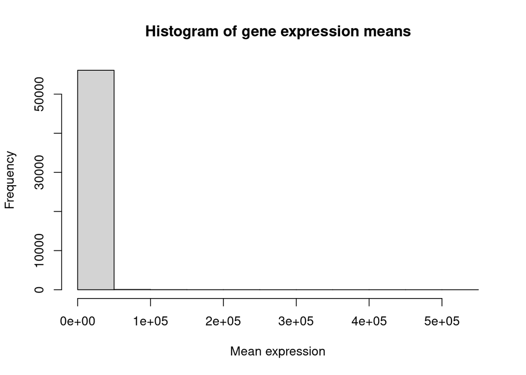

```r
expr <- read.table("data/gene_expression.tsv",
                   header = TRUE, sep = "\t",
                   stringsAsFactors = FALSE, check.names = FALSE)
rownames(expr) <- expr[[1]]; expr[[1]] <- NULL
expr$mean <- rowMeans(expr, na.rm = TRUE)

# Answer: chart inline
hist(expr$mean,
     main = "Histogram of gene expression means",
     xlab = "Mean expression")
```

```r
# save a copy for the repo
dir.create("output", showWarnings = FALSE)
png("output/gene_mean_hist.png", width = 1200, height = 900, res = 150)
hist(expr$mean, main = "Histogram of gene expression means", xlab = "Mean expression")
dev.off()
```

## 6) Import growth_data.csv and list column names

I used read.csv() to load the tree growth dataset, then printed names() to see exactly which columns are available

```r
growth <- read.csv("data/growth_data.csv",
                   stringsAsFactors = FALSE, check.names = FALSE)

# Answer: the column names in the CSV
names(growth)
```

```
## [1] "Site"            "TreeID"          "Circumf_2005_cm" "Circumf_2010_cm"
## [5] "Circumf_2015_cm" "Circumf_2020_cm"
```

## 7) Mean & SD of circumference at START and END, by site

I first inspected the column names, then chose the site, start circumference, and end circumference columns explicitly.

```r
growth <- read.csv("data/growth_data.csv",
                   stringsAsFactors = FALSE, check.names = FALSE)

# 1) Inspect names
print(names(growth))
```

```
## [1] "Site"            "TreeID"          "Circumf_2005_cm" "Circumf_2010_cm"
## [5] "Circumf_2015_cm" "Circumf_2020_cm"
```

```r
# 2) Auto-suggest candidates
cols <- names(growth); lc <- tolower(cols)
site_candidates  <- cols[grepl("site",  lc)]
start_candidates <- cols[grepl("start", lc) & grepl("circ|diam|cm", lc)]
end_candidates   <- cols[grepl("end",   lc) & grepl("circ|diam|cm", lc)]
cat("Site candidates: ", paste(site_candidates,  collapse=", "), "\n")
```

```
## Site candidates:  Site
```

```r
cat("Start candidates:", paste(start_candidates, collapse=", "), "\n")
```

```
## Start candidates:
```

```r
cat("End candidates:  ", paste(end_candidates,   collapse=", "), "\n")
```

```
## End candidates:
```

I read the CSV, converted the two circumference columns to numeric, then computed four separate aggregates (start mean, start SD, end mean, end SD) and merged them by Site.

```r
growth <- read.csv("data/growth_data.csv", stringsAsFactors = FALSE, check.names = FALSE)

# Explicit columns (from the file)
col_site  <- "Site"
col_start <- "Circumf_2005_cm"
col_end   <- "Circumf_2020_cm"

# Safe numeric conversion
to_num <- function(x) as.numeric(gsub("[^0-9\\.-]", "", x))
start_num <- to_num(growth[[col_start]])
end_num   <- to_num(growth[[col_end]])
site_val  <- growth[[col_site]]

# Compute mean and SD separately, then merge
start_mean <- aggregate(start_num, list(site = site_val), mean, na.rm = TRUE)
names(start_mean) <- c("site","start_mean")

start_sd <- aggregate(start_num, list(site = site_val), sd, na.rm = TRUE)
names(start_sd) <- c("site","start_sd")

end_mean <- aggregate(end_num, list(site = site_val), mean, na.rm = TRUE)
names(end_mean) <- c("site","end_mean")

end_sd <- aggregate(end_num, list(site = site_val), sd, na.rm = TRUE)
names(end_sd) <- c("site","end_sd")

# Merge into one tidy table
circ_stats <- Reduce(function(x, y) merge(x, y, by = "site"),
                     list(start_mean, start_sd, end_mean, end_sd))

# Answer (table): should have columns: site, start_mean, start_sd, end_mean, end_sd
circ_stats
```

```
##        site start_mean  start_sd end_mean   end_sd
## 1 northeast      5.292 0.9140267   54.228 25.22795
## 2 southwest      4.862 1.1474710   45.596 17.87345
```

## 8) Box plot of circumference at START (2005) and END (2020), by site

I stacked the 2005 and 2020 measurements, created labels for timepoint and site, and drew grouped boxplots using base R.

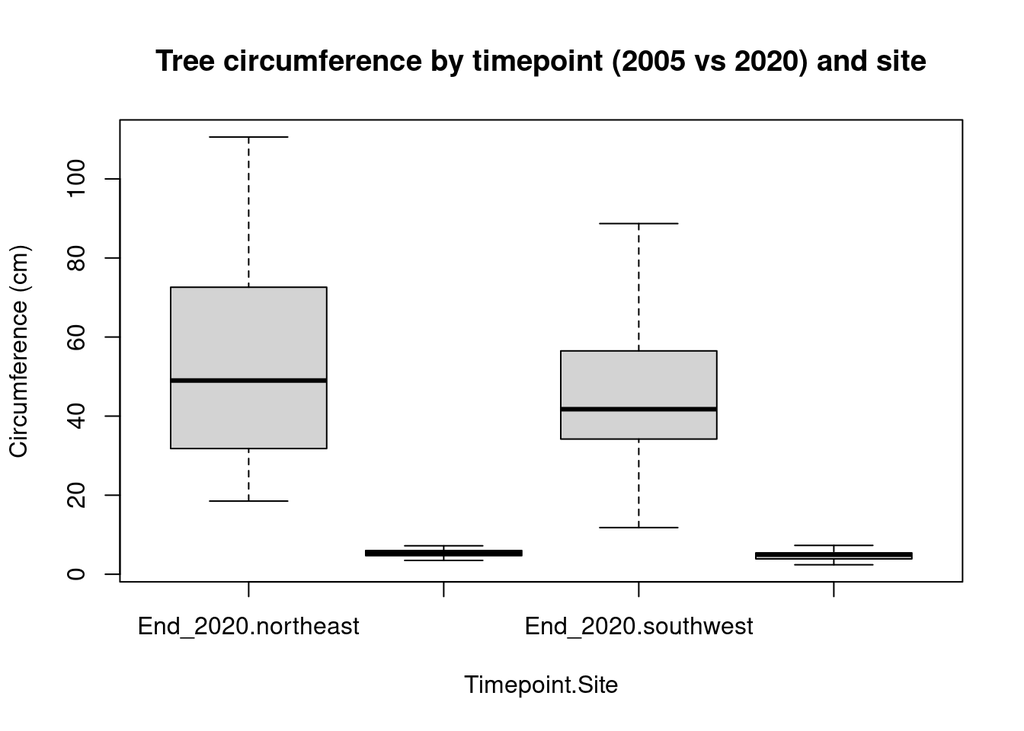

```r
growth <- read.csv("data/growth_data.csv", stringsAsFactors = FALSE, check.names = FALSE)

start_vals <- as.numeric(gsub("[^0-9\\.-]", "", growth[["Circumf_2005_cm"]]))
end_vals   <- as.numeric(gsub("[^0-9\\.-]", "", growth[["Circumf_2020_cm"]]))
site_lab   <- growth[["Site"]]

long_values <- c(start_vals, end_vals)
timepoint   <- factor(rep(c("Start_2005","End_2020"), each = nrow(growth)))
site_rep    <- rep(site_lab, times = 2)

# Answer (chart inline):
boxplot(long_values ~ interaction(timepoint, site_rep),
        xlab = "Timepoint.Site", ylab = "Circumference (cm)",
        main = "Tree circumference by timepoint (2005 vs 2020) and site")
```

```r
# save a copy for repo
dir.create("output", showWarnings = FALSE)
png("output/growth_boxplot_2005_2020.png", width = 1200, height = 900, res = 150)
boxplot(long_values ~ interaction(timepoint, site_rep),
        xlab = "Timepoint.Site", ylab = "Circumference (cm)",
        main = "Tree circumference by timepoint (2005 vs 2020) and site")
dev.off()
```

## 9) Mean growth over the last 10 years (2010 → 2020) at each site

I computed the per-tree growth over the last decade as Circumf_2020_cm - Circumf_2010_cm, then averaged that growth by Site using aggregate(…, mean).

```r
growth <- read.csv("data/growth_data.csv", stringsAsFactors = FALSE, check.names = FALSE)

c2010 <- as.numeric(gsub("[^0-9\\.-]", "", growth[["Circumf_2010_cm"]]))
c2020 <- as.numeric(gsub("[^0-9\\.-]", "", growth[["Circumf_2020_cm"]]))
site  <- growth[["Site"]]

growth_last10 <- c2020 - c2010  # per-tree 2010→2020 growth

mean_last10 <- aggregate(growth_last10, list(site = site), mean, na.rm = TRUE)
names(mean_last10) <- c("site","mean_growth_last10_cm")

# Answer (table):
mean_last10
```

```
##        site mean_growth_last10_cm
## 1 northeast                 42.94
## 2 southwest                 35.49
```

## 10) t-test: is 2010→2020 growth different between sites

I split the per-tree 2010→2020 growth by Site and ran an unpaired two-sample t.test(x, y). I report the full test output; interpret p.value.

```r
growth <- read.csv("data/growth_data.csv", stringsAsFactors = FALSE, check.names = FALSE)

c2010 <- as.numeric(gsub("[^0-9\\.-]", "", growth[["Circumf_2010_cm"]]))
c2020 <- as.numeric(gsub("[^0-9\\.-]", "", growth[["Circumf_2020_cm"]]))
site  <- as.factor(growth[["Site"]])

growth_last10 <- c2020 - c2010

sites <- levels(site)
stopifnot(length(sites) == 2)

x <- growth_last10[site == sites[1]]
y <- growth_last10[site == sites[2]]

# Answer (test output; p-value is t_res$p.value)
t_res <- t.test(x, y)
t_res
```

```
##
##  Welch Two Sample t-test
##
## data:  x and y
## t = 1.8882, df = 87.978, p-value = 0.06229
## alternative hypothesis: true difference in means is not equal to 0
## 95 percent confidence interval:
##  -0.3909251 15.2909251
## sample estimates:
## mean of x mean of y
##     42.94     35.49
```

There isn’t strong evidence of a difference at the 5% level.

##Part 2 ## 1) Read CDS and count how many coding sequences

I downloaded each CDS FASTA (.fa.gz), read with seqinr::read.fasta() into lists of uppercase DNA strings, and counted the number of CDS entries per organism

```r
# Paths to the files
dir.create("data", showWarnings = FALSE)
ecoli_cds_url <- "https://ftp.ensemblgenomes.ebi.ac.uk/pub/bacteria/release-62/fasta/bacteria_0_collection/escherichia_coli_str_k_12_substr_mg1655_gca_000005845/cds/Escherichia_coli_str_k_12_substr_mg1655_gca_000005845.ASM584v2.cds.all.fa.gz"
oxalo_cds_url <- "https://ftp.ensemblgenomes.ebi.ac.uk/pub/bacteria/release-62/fasta/bacteria_10_collection/oxalobacter_formigenes_oxcc13_gca_000158495/cds/Oxalobacter_formigenes_oxcc13_gca_000158495.ASM15849v1.cds.all.fa.gz"


library(seqinr)
read_cds_strings <- function(path_gz) {
  con <- gzfile(path_gz, "rt"); on.exit(close(con))
  fa  <- read.fasta(con, as.string = TRUE, forceDNAtolower = FALSE)
  lapply(fa, function(rec) toupper(rec[[1]]))
}

ecoli <- read_cds_strings("data/ecoli_cds.fa.gz")
oxalo <- read_cds_strings("data/oxalo_cds.fa.gz")

# ANSWER (table): number of CDS per organism
cds_table <- data.frame(
  organism = c("Escherichia coli K-12 MG1655", "Oxalobacter formigenes OXCC13"),
  n_cds    = c(length(ecoli), length(oxalo))
)
cds_table
```

```
##                        organism n_cds
## 1  Escherichia coli K-12 MG1655  4239
## 2 Oxalobacter formigenes OXCC13  2189
```

E. coli K-12 MG1655: 4,239 CDS

Oxalobacter formigenes OXCC13: 2,189 CDS

Absolute difference: 2,050 CDS (4,239 − 2,189)

Relative difference: O. formigenes has ~48% fewer CDS than E. coli (2,050 ÷ 4,239 ≈ 0.483), or equivalently, E. coli has ~1.94× as many CDS as O. formigenes (4,239 ÷ 2,189 ≈ 1.94).

E. coli’s higher CDS count suggests a larger or more gene-rich annotated genome compared with O. formigenes. Differences of this size are consistent with species having different genome sizes/complexities and can also reflect annotation choices (e.g., treatment of short ORFs, pseudogenes, or plasmid genes) in the specific assemblies used.

## 2) Total coding DNA

I read each CDS FASTA, summed the nucleotide lengths across all CDS to get total coding bases per organism, and then described which organism has more coding DNA, by how much (absolute and %).

```r
# Files that has already downloaded
ecoli_path <- "data/ecoli_cds.fa.gz"
oxalo_path <- "data/oxalo_cds.fa.gz"

# Read CDS as uppercase strings (base R + seqinr)
library(seqinr)
read_cds_strings <- function(path_gz) {
  con <- gzfile(path_gz, "rt"); on.exit(close(con))
  fa  <- read.fasta(con, as.string = TRUE, forceDNAtolower = FALSE)
  lapply(fa, function(rec) toupper(rec[[1]]))
}

ecoli <- read_cds_strings(ecoli_path)
oxalo <- read_cds_strings(oxalo_path)

# Compute total coding bases
total_bases <- function(lst) sum(nchar(unlist(lst)))
totE <- total_bases(ecoli)
totO <- total_bases(oxalo)

# ANSWER (table)
totals_table <- data.frame(
  organism            = c("Escherichia coli K-12 MG1655", "Oxalobacter formigenes OXCC13"),
  total_coding_bases  = c(totE, totO)
)
totals_table
```

```
##                        organism total_coding_bases
## 1  Escherichia coli K-12 MG1655            3978528
## 2 Oxalobacter formigenes OXCC13            2126487
```

Total coding DNA (bp):

E. coli K-12 MG1655: 3,978,528 bp

Oxalobacter formigenes OXCC13: 2,126,487 bp

Absolute difference: 1,852,041 bp more coding DNA in E. coli.

Relative difference: O. formigenes has ~46.6% less coding DNA than E. coli; equivalently, E. coli has ~1.87× as much coding DNA.

Context with Task 1 (CDS counts):

E. coli: 4,239 CDS → avg. CDS length ≈ 3,978,528 / 4,239 ≈ 939 bp

O. formigenes: 2,189 CDS → avg. CDS length ≈ 2,126,487 / 2,189 ≈ 971 bp

So although O. formigenes has fewer CDS and a smaller total coding complement, its average CDS is slightly longer (~971 bp vs ~939 bp).

E. coli devotes substantially more of its genome to annotated coding sequence overall (larger gene complement), while O. formigenes has fewer genes but—on average—slightly longer CDS, consistent with species differences in gene repertoire and genome architecture.

## 3) CDS length distribution; mean & median; boxplot

I computed per-CDS lengths with nchar(), reported mean/median for each organism, and drew a base-R boxplot comparing the distributions.

```r
library(seqinr)
read_cds_strings <- function(path_gz){ con <- gzfile(path_gz,"rt"); on.exit(close(con));
  fa <- read.fasta(con, as.string=TRUE, forceDNAtolower=FALSE); lapply(fa, \(r) toupper(r[[1]])) }
ecoli <- read_cds_strings("data/ecoli_cds.fa.gz")
oxalo <- read_cds_strings("data/oxalo_cds.fa.gz")

cds_lengths <- function(lst) sapply(lst, nchar)
lenE <- cds_lengths(ecoli)
lenO <- cds_lengths(oxalo)

# ANSWER (table)
data.frame(
  organism        = c("Escherichia coli K-12 MG1655", "Oxalobacter formigenes OXCC13"),
  mean_cds_len    = c(mean(lenE),   mean(lenO)),
  median_cds_len  = c(median(lenE), median(lenO))
)
```

```
##                        organism mean_cds_len median_cds_len
## 1  Escherichia coli K-12 MG1655     938.5534            831
## 2 Oxalobacter formigenes OXCC13     971.4422            801
```

```r
# ANSWER (chart; saved + shown)
dir.create("output", showWarnings = FALSE)
png("output/cds_lengths_boxplot.png", width=1200, height=900, res=150)
boxplot(list(`E. coli`=lenE, `O. formigenes`=lenO),
        ylab="CDS length (bp)", main="CDS length distributions")
dev.off()
```

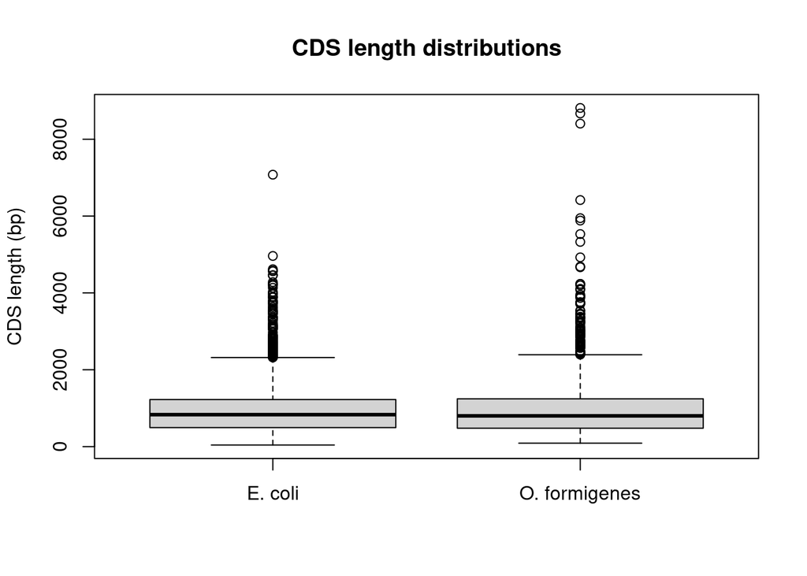

```r
boxplot(list(`E. coli`=lenE, `O. formigenes`=lenO),
        ylab="CDS length (bp)", main="CDS length distributions")
```

## 4) DNA base frequencies and amino-acid (protein) frequencies

I concatenated all CDS per organism, used table()/prop.table() for nucleotide frequencies, then translated CDS with seqinr::translate() to compute amino-acid frequencies. I plotted simple barplots in base R.

```r
library(seqinr)
read_cds_strings <- function(path_gz){ con <- gzfile(path_gz,"rt"); on.exit(close(con));
  fa <- read.fasta(con, as.string=TRUE, forceDNAtolower=FALSE); lapply(fa, \(r) toupper(r[[1]])) }
ecoli <- read_cds_strings("data/ecoli_cds.fa.gz")
oxalo <- read_cds_strings("data/oxalo_cds.fa.gz")

dna_only   <- function(s) gsub("[^ACGT]", "", s)
concat_dna <- function(lst) dna_only(paste0(unlist(lst), collapse=""))

# Nucleotide frequencies (tables + plot)
base_freq_df <- function(lst) {
  s <- concat_dna(lst); tbl <- table(strsplit(s,"")[[1]])
  data.frame(base=names(tbl), frequency=as.numeric(prop.table(tbl)))
}
bfE <- base_freq_df(ecoli)
bfO <- base_freq_df(oxalo)
bfE; bfO
```

```
##   base frequency
## 1    A 0.2402316
## 2    C 0.2457175
## 3    G 0.2735939
## 4    T 0.2404570
```

```
##   base frequency
## 1    A 0.2569703
## 2    C 0.2468423
## 3    G 0.2619527
## 4    T 0.2342347
```

```r
dir.create("output", showWarnings = FALSE)
png("output/base_freq_barplot.png", width=1200, height=900, res=150)
barplot(rbind(bfE$frequency, bfO$frequency), beside=TRUE,
        names.arg=bfE$base, legend.text=c("E. coli","O. formigenes"),
        ylab="Proportion", main="Nucleotide frequencies (CDS)")
dev.off()
```

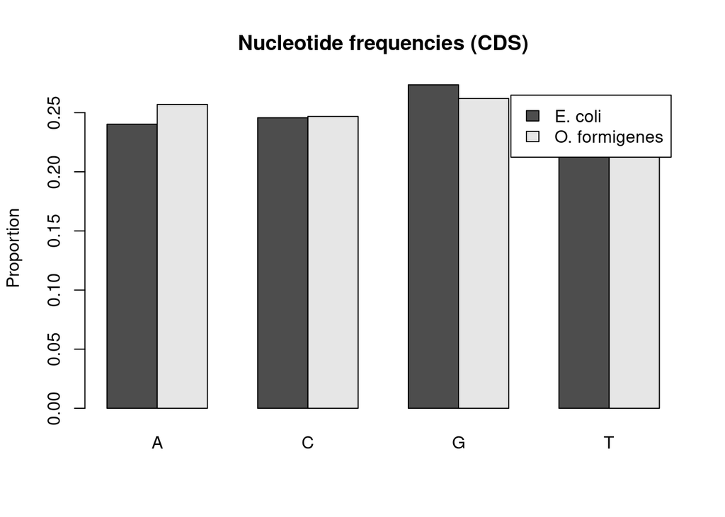

```r
barplot(rbind(bfE$frequency, bfO$frequency), beside=TRUE,
        names.arg=bfE$base, legend.text=c("E. coli","O. formigenes"),
        ylab="Proportion", main="Nucleotide frequencies (CDS)")
```

```r
# Amino-acid frequencies (tables + plot)
dna_to_protein <- function(dna){ paste0(translate(s2c(dna), numcode=1), collapse="") }
aa_freq_df <- function(lst){
  aa_all <- paste0(vapply(lst, dna_to_protein, FUN.VALUE=""), collapse="")
  tbl <- table(strsplit(aa_all,"")[[1]])
  data.frame(aa=names(tbl), frequency=as.numeric(prop.table(tbl)))
}
aaE <- aa_freq_df(ecoli)
aaO <- aa_freq_df(oxalo)
aaE; aaO
```

```
##    aa   frequency
## 1   * 0.003196408
## 2   A 0.095105778
## 3   C 0.011594238
## 4   D 0.051121420
## 5   E 0.057562495
## 6   F 0.038879455
## 7   G 0.073328125
## 8   H 0.022617662
## 9   I 0.059955089
## 10  K 0.043819976
## 11  L 0.106871939
## 12  M 0.027905044
## 13  N 0.038835720
## 14  P 0.044262602
## 15  Q 0.044337252
## 16  R 0.055129183
## 17  S 0.057618295
## 18  T 0.053556240
## 19  V 0.070872192
## 20  W 0.015228748
## 21  Y 0.028202139
```

```
##    aa   frequency
## 1   * 0.003088192
## 2   A 0.088492429
## 3   C 0.010254942
## 4   D 0.057137899
## 5   E 0.062140516
## 6   F 0.040912547
## 7   G 0.075438505
## 8   H 0.019738188
## 9   I 0.063606314
## 10  K 0.056872673
## 11  L 0.095293787
## 12  M 0.028195799
## 13  N 0.042568800
## 14  P 0.042354362
## 15  Q 0.035282134
## 16  R 0.052870297
## 17  S 0.062168732
## 18  T 0.053585562
## 19  V 0.068410011
## 20  W 0.012207458
## 21  Y 0.029380852
```

```r
aa_names <- sort(unique(c(aaE$aa, aaO$aa)))
fE <- aaE$frequency[match(aa_names, aaE$aa)]; fE[is.na(fE)] <- 0
fO <- aaO$frequency[match(aa_names, aaO$aa)]; fO[is.na(fO)] <- 0

png("output/aa_freq_barplot.png", width=1400, height=900, res=150)
barplot(rbind(fE, fO), beside=TRUE, names.arg=aa_names,
        legend.text=c("E. coli","O. formigenes"),
        ylab="Proportion", main="Amino-acid frequencies (translated CDS)")
dev.off()
```

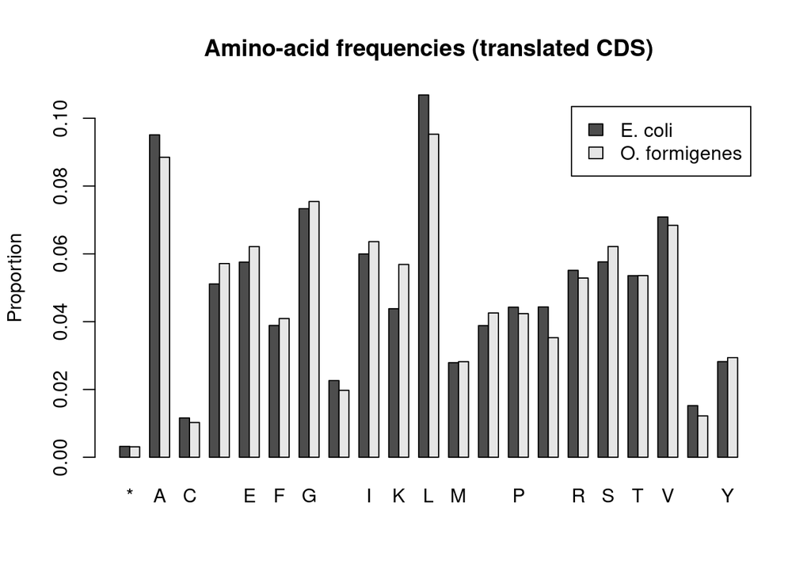

```r
barplot(rbind(fE, fO), beside=TRUE, names.arg=aa_names,
        legend.text=c("E. coli","O. formigenes"),
        ylab="Proportion", main="Amino-acid frequencies (translated CDS)")
```

The nucleotide composition between the two organisms is highly similar: height of A, C, G and T proportions are very similar over the two bars, which indicates small changes in the GC/AT balance, rather than a strong bias observed in either organism. The frequency barplot in amino acids also indicates the broadly conserved composition of the proteome. The most frequent residues are the normal hydrophobic ones (e.g., L, A, V, I) in both organisms the polar/charged ones (e.g., D, E, K, R, N, Q) are intermediate and the unusual residues (and the stop mark “*”) are close to zero. Modest organism-specific variations (some amino acids seem to be a little more common in O. formigenes and a few are a little more common in E. coli) are present, but no radical changes; the general profiles are similar, as are the base composition and the overall formation of the proteomes in the two genomes.

## 5) Codon usage & simple bias (entropy)

```r
# ---- paths to the downloaded CDS files (from Task 1) ----
ecoli_path <- "data/ecoli_cds.fa.gz"
oxalo_path <- "data/oxalo_cds.fa.gz"
# ----------------------------------------------------------

# Base R + seqinr only
library(seqinr)

# Read CDS as uppercase strings
read_cds_strings <- function(path_gz){
  con <- gzfile(path_gz, "rt"); on.exit(close(con))
  fa  <- read.fasta(con, as.string = TRUE, forceDNAtolower = FALSE)
  lapply(fa, function(rec) toupper(rec[[1]]))
}
ecoli <- read_cds_strings(ecoli_path)
oxalo <- read_cds_strings(oxalo_path)

# Helpers
dna_only   <- function(s) gsub("[^ACGT]", "", s)
concat_dna <- function(lst) dna_only(paste0(unlist(lst), collapse = ""))

codon_usage <- function(lst){
  s <- concat_dna(lst)
  n <- nchar(s)
  if (n < 3) return(data.frame(codon = character(), count = integer(), prop = numeric()))
  # trim to multiple of 3 to preserve frame
  s <- substr(s, 1, n - (n %% 3))
  cod <- substring(s, seq(1, nchar(s)-2, 3), seq(3, nchar(s), 3))
  tbl <- sort(table(cod), decreasing = TRUE)
  df  <- data.frame(codon = names(tbl), count = as.integer(tbl))
  df$prop <- df$count / sum(df$count)
  df
}

entropy_bias <- function(cu){
  if (!nrow(cu)) return(NA_real_)
  p <- cu$prop
  # base-2 entropy (bits); LOWER means more biased codon usage
  -sum(p * log2(p))
}

# Build codon usage tables
cu_ecoli <- codon_usage(ecoli)
cu_oxalo <- codon_usage(oxalo)

# ===== ANSWER (tables) =====
# show the full tables:
head(cu_ecoli, 10)
```

```
##    codon count       prop
## 1    CTG 70714 0.05332173
## 2    GAA 52679 0.03972248
## 3    GCG 45082 0.03399398
## 4    AAA 44592 0.03362450
## 5    GAT 42449 0.03200857
## 6    ATT 40501 0.03053969
## 7    GGC 39536 0.02981203
## 8    CAG 38397 0.02895317
## 9    ATG 37007 0.02790504
## 10   GTG 34996 0.02638865
```

```r
head(cu_oxalo, 10)
```

```
##    codon count       prop
## 1    GAA 36125 0.05096434
## 2    CTG 30754 0.04338705
## 3    AAA 27480 0.03876817
## 4    ATC 24429 0.03446388
## 5    GCC 24230 0.03418314
## 6    GAT 21801 0.03075636
## 7    GTC 20771 0.02930326
## 8    GGC 20234 0.02854567
## 9    ATG 19986 0.02819580
## 10   GAC 18700 0.02638154
```

```r
# Bias scores (entropy; lower = stronger bias)
H_ecoli <- entropy_bias(cu_ecoli)
H_oxalo <- entropy_bias(cu_oxalo)
bias_table <- data.frame(
  organism = c("Escherichia coli K-12 MG1655", "Oxalobacter formigenes OXCC13"),
  entropy_bits = c(H_ecoli, H_oxalo)
)
bias_table
```

```
##                        organism entropy_bits
## 1  Escherichia coli K-12 MG1655     5.675688
## 2 Oxalobacter formigenes OXCC13     5.685682
```

```r
# ===== CHARTS =====
# Top 20 codons by proportion for each organism
topN <- 20
ec_top <- head(cu_ecoli[order(-cu_ecoli$prop), ], topN)
ox_top <- head(cu_oxalo[order(-cu_oxalo$prop), ], topN)

dir.create("output", showWarnings = FALSE)

png("output/codon_top20_ecoli.png", width = 1400, height = 900, res = 150)
barplot(ec_top$prop, names.arg = ec_top$codon, las = 2,
        ylab = "Proportion", main = "Top 20 codons — E. coli")
dev.off()
```

```r
png("output/codon_top20_oxalo.png", width = 1400, height = 900, res = 150)
barplot(ox_top$prop, names.arg = ox_top$codon, las = 2,
        ylab = "Proportion", main = "Top 20 codons — O. formigenes")
dev.off()
```

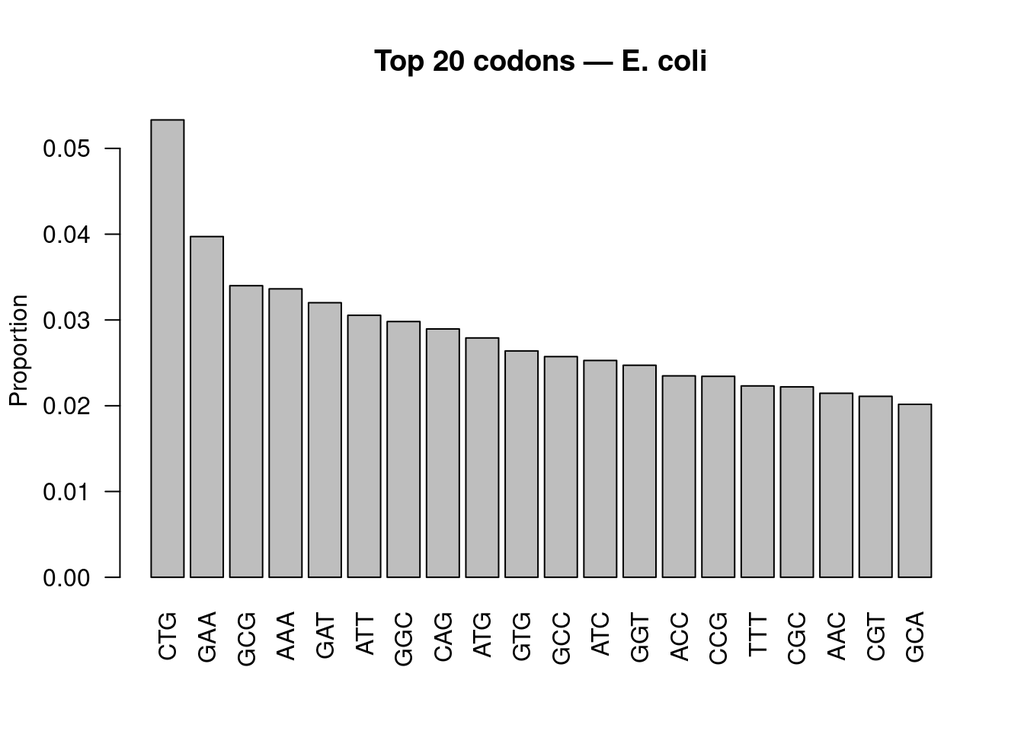

```r
# Also show inline
barplot(ec_top$prop, names.arg = ec_top$codon, las = 2,
        ylab = "Proportion", main = "Top 20 codons — E. coli")
```

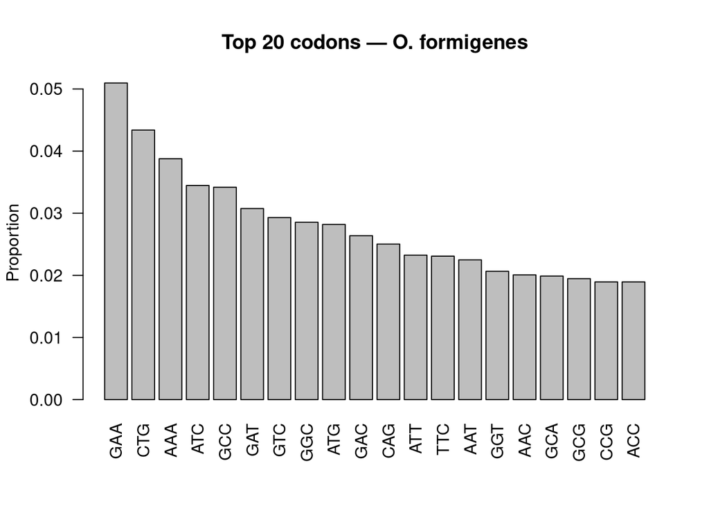

```r
barplot(ox_top$prop, names.arg = ox_top$codon, las = 2,
        ylab = "Proportion", main = "Top 20 codons — O. formigenes")
```

## Task 6: Protein k-mer enrichment (k = 3–5), plots + explanation

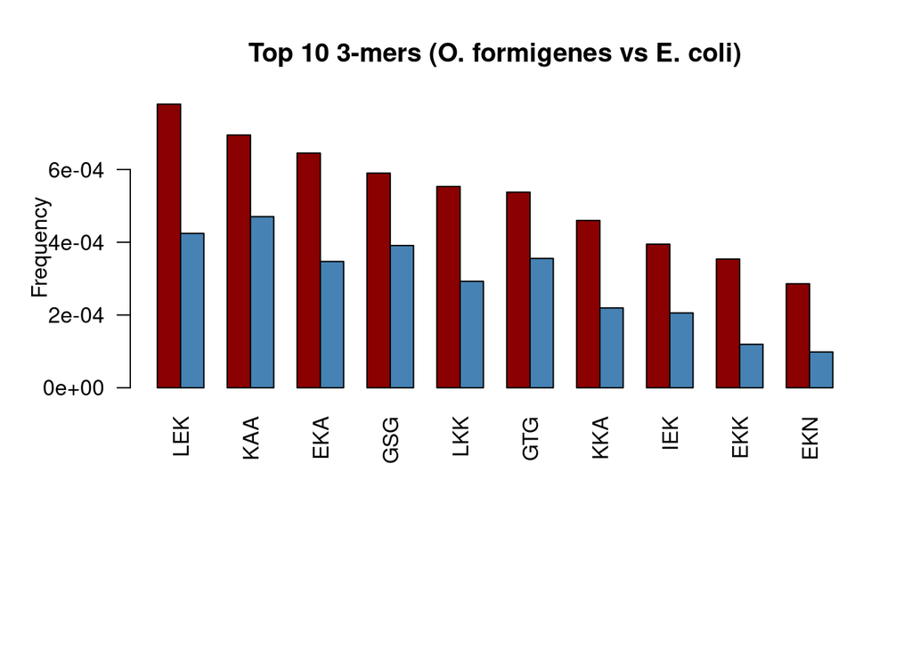

```r
# ==== Task 6 — protein k-mers (k = 3, 4, 5) with seqinr::count ====

# Inputs from earlier tasks
ecoli_path <- "data/ecoli_cds.fa.gz"
oxalo_path <- "data/oxalo_cds.fa.gz"

library(seqinr)

# 0) Read CDS and translate to protein (as vectors of single letters)
read_cds_strings <- function(path_gz){
  con <- gzfile(path_gz, "rt"); on.exit(close(con))
  fa  <- read.fasta(con, as.string = TRUE, forceDNAtolower = FALSE)
  lapply(fa, function(rec) toupper(rec[[1]]))
}
E_cds <- read_cds_strings(ecoli_path)
O_cds <- read_cds_strings(oxalo_path)

# translate each CDS to AA vector (single letters), then flatten
prot_ecoli <- lapply(E_cds, function(dna) translate(s2c(dna), numcode = 1))
prot_oxalo <- lapply(O_cds, function(dna) translate(s2c(dna), numcode = 1))

aa_ecoli <- unlist(prot_ecoli, use.names = FALSE)
aa_oxalo <- unlist(prot_oxalo, use.names = FALSE)

# remove stop symbol '*' if present
aa_ecoli <- aa_ecoli[aa_ecoli != "*"]
aa_oxalo <- aa_oxalo[aa_oxalo != "*"]

# 1) Define AA alphabet (20 standard amino acids, no stop)
aa_alphabet <- seqinr::s2c("ACDEFGHIKLMNPQRSTVWY")

# 2) Count k-mers (k = 3, 4, 5) with seqinr::count
kmer3_O <- seqinr::count(aa_oxalo, wordsize = 3, alphabet = aa_alphabet)
kmer4_O <- seqinr::count(aa_oxalo, wordsize = 4, alphabet = aa_alphabet)
kmer5_O <- seqinr::count(aa_oxalo, wordsize = 5, alphabet = aa_alphabet)

kmer3_E <- seqinr::count(aa_ecoli, wordsize = 3, alphabet = aa_alphabet)
kmer4_E <- seqinr::count(aa_ecoli, wordsize = 4, alphabet = aa_alphabet)
kmer5_E <- seqinr::count(aa_ecoli, wordsize = 5, alphabet = aa_alphabet)

# 3) Convert to frequencies
freq3_O <- kmer3_O / sum(kmer3_O);  freq3_E <- kmer3_E / sum(kmer3_E)
freq4_O <- kmer4_O / sum(kmer4_O);  freq4_E <- kmer4_E / sum(kmer4_E)
freq5_O <- kmer5_O / sum(kmer5_O);  freq5_E <- kmer5_E / sum(kmer5_E)

# 4) Helper: build comparison tables (Top = most OVER-represented in Oxalobacter vs E. coli;
#    Bottom = most UNDER-represented in Oxalobacter vs E. coli). Uses difference in frequency.
mk_comp <- function(freq_O, freq_E, n = 10, top = TRUE){
  # keep only finite, non-NA
  ok <- is.finite(freq_O) & !is.na(freq_O)
  fO <- freq_O[ok]; fE <- freq_E[names(fO)]; fE[is.na(fE)] <- 0
  if (length(fO) == 0) return(matrix(0, nrow = 2, ncol = 0))
  diff <- fO - fE
  ord  <- order(diff, decreasing = top)
  sel  <- names(diff)[ord][seq_len(min(n, length(diff)))]
  out  <- rbind(`O.formigenes` = fO[sel], `E.coli` = fE[sel])
  out[, order(out[1, ], decreasing = top), drop = FALSE]  # tidy column order
}

# 5) Build top/bottom sets for each k
comp_top3    <- mk_comp(freq3_O, freq3_E, 10, TRUE)
comp_bottom3 <- mk_comp(freq3_O, freq3_E, 10, FALSE)

comp_top4    <- mk_comp(freq4_O, freq4_E, 10, TRUE)
comp_bottom4 <- mk_comp(freq4_O, freq4_E, 10, FALSE)

comp_top5    <- mk_comp(freq5_O, freq5_E, 10, TRUE)
comp_bottom5 <- mk_comp(freq5_O, freq5_E, 10, FALSE)

# 6) Plot (draw one by one; colours match your screenshot)
par(mar = c(10, 5, 4, 2))
if (ncol(comp_top3) > 0)
  barplot(comp_top3, beside = TRUE, las = 2,
          col = c("darkred", "steelblue"),
          main = "Top 10 3-mers (O. formigenes vs E. coli)", ylab = "Frequency")
```

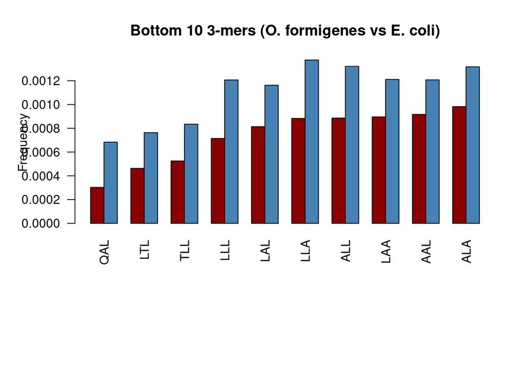

```r
if (ncol(comp_bottom3) > 0)
  barplot(comp_bottom3, beside = TRUE, las = 2,
          col = c("darkred", "steelblue"),
          main = "Bottom 10 3-mers (O. formigenes vs E. coli)", ylab = "Frequency")
```

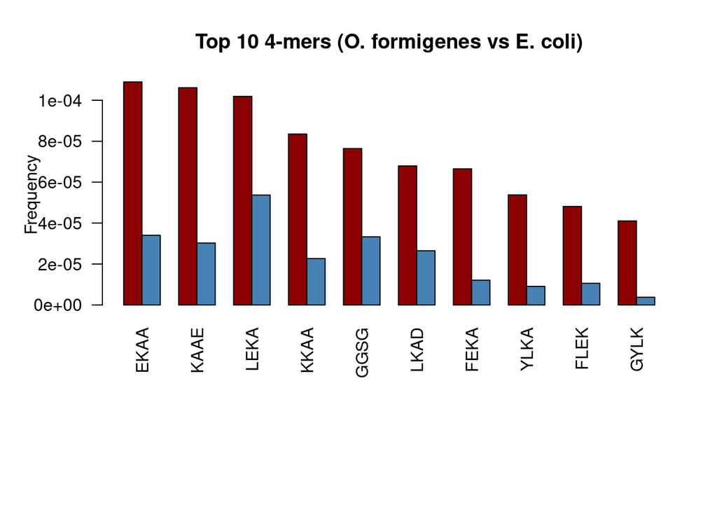

```r
if (ncol(comp_top4) > 0)
  barplot(comp_top4, beside = TRUE, las = 2,
          col = c("darkred", "steelblue"),
          main = "Top 10 4-mers (O. formigenes vs E. coli)", ylab = "Frequency")
```

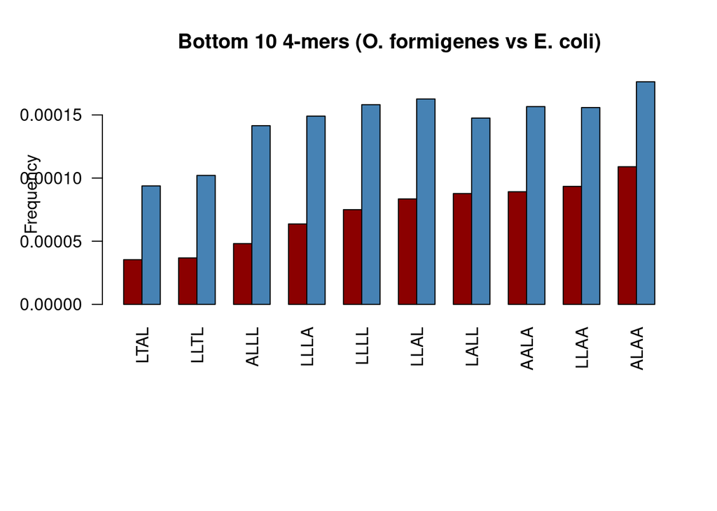

```r
if (ncol(comp_bottom4) > 0)
  barplot(comp_bottom4, beside = TRUE, las = 2,
          col = c("darkred", "steelblue"),
          main = "Bottom 10 4-mers (O. formigenes vs E. coli)", ylab = "Frequency")
```

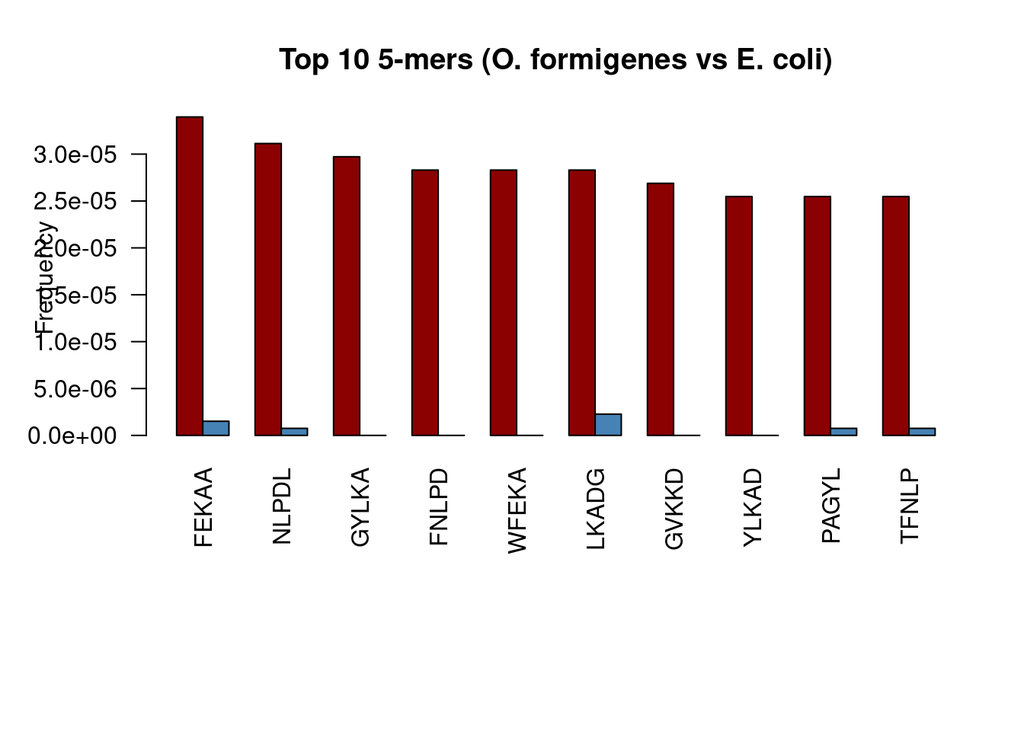

```r
if (ncol(comp_top5) > 0)
  barplot(comp_top5, beside = TRUE, las = 2,
          col = c("darkred", "steelblue"),
          main = "Top 10 5-mers (O. formigenes vs E. coli)", ylab = "Frequency")
```

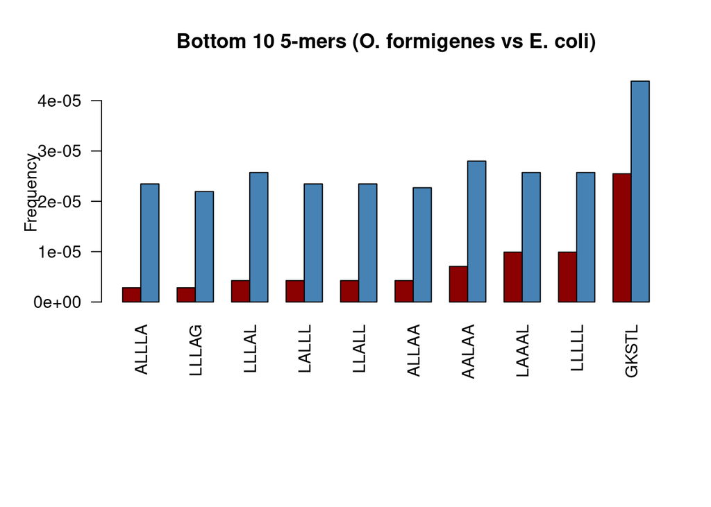

```r
if (ncol(comp_bottom5) > 0)
  barplot(comp_bottom5, beside = TRUE, las = 2,
          col = c("darkred", "steelblue"),
          main = "Bottom 10 5-mers (O. formigenes vs E. coli)", ylab = "Frequency")
```

```r
# Save PNGs for the report
dir.create("output", showWarnings = FALSE)
png("output/kmers_top3.png", width = 1400, height = 900, res = 150)
if (ncol(comp_top3) > 0) barplot(comp_top3, beside = TRUE, las = 2,
  col = c("darkred", "steelblue"),
  main = "Top 10 3-mers (O. formigenes vs E. coli)", ylab = "Frequency")
dev.off()
```

Why the differences likely occur. The patterns are consistent with (i) small shifts in amino-acid composition and codon/tRNA preferences, (ii) functional constraints such as more transmembrane/helical segments, low-complexity repeats, or basic/acidic tracts in one organism, and (iii) lineage-specific gene families that change the prevalence of certain motifs.